# 1.3. Polynomial Regression

Linear regression requires the relation between the dependent variable and the independent variable to be linear. Often, the relationship between the dependent variable Y and one or more of the independent X variables is not a straight-line relationship but, rather, has some curvature to it.

Say, the relationship between X & Y is curvilinear. How can we generate a curve that best captures the data for several such situations as shown below?

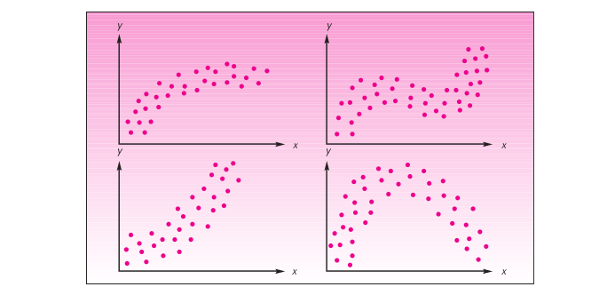

In each of the situations shown, a straight line provides a poor fit to the data. In such a cases, we can Polynomial Regression.

**Polynomial regression is a special case of Multiple Linear Regression where we fit a polynomial equation on the data with a curvilinear relationship between the target variable and the independent variables.**

A one-variable polynomial regression model is:

$Y = \beta_0 + \beta_1X + \beta_2{X}^2 + \beta_3{X}^3... + \beta_m X^m + \epsilon$

where $m$ is the **degree of the polynomial**—the highest power of $X$ appearing in the equation. The degree of the polynomial is the order of the model.

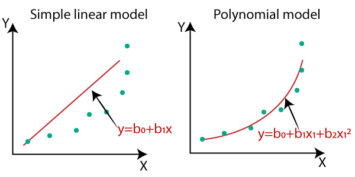

In the previous examples, we can try polynomial fitting with different degrees

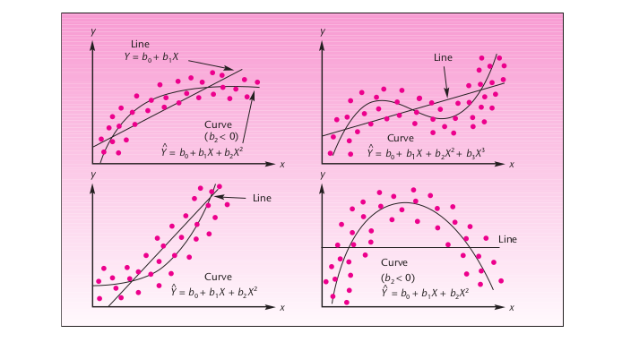

Above figure shows how second- and third-degree polynomial models provide good fits to the data as compared to a straight line (linear) fit.

Hence, Polynomial Regression is a special case of linear regression, by the fact that we create some polynomial features before creating a Linear Regression.

**But why Polynomial Regression still considered as Linear Regression or is also called as Polynomial Linear regression ?** Even though polynomial regression has power > 1, it is still called linear. This is because when we talk about linear, we don’t look at it from the point of view of the x-variable. We talk about coefficients. Y is a function of X. Can this function be expressed as a linear combination of coefficients because ultimately used to plugin X and predict Y. Hence, by just looking at the equation from the coefficients point of view, makes it linear. Interesting right?

```python
import pandas as pd
import matplotlib.pyplot as plt
import numpy as np

weather_data = pd.read_csv("./WeatherData.csv")

weather_data
```

|  | Pressure (millibars) | Humidity |
| --- | --- | --- |
| 0 | 1014.40 | 0.62 |
| 1 | 1014.20 | 0.66 |
| 2 | 1014.47 | 0.79 |
| 3 | 1014.45 | 0.82 |
| 4 | 1014.49 | 0.83 |
| 5 | 1014.52 | 0.85 |
| 6 | 1014.16 | 0.83 |
| 7 | 1014.24 | 0.78 |
| 8 | 1014.25 | 0.72 |
| 9 | 1013.96 | 0.61 |
| 10 | 1013.85 | 0.52 |
| 11 | 1013.04 | 0.46 |
| 12 | 1012.22 | 0.40 |
| 13 | 1011.44 | 0.40 |
| 14 | 1010.52 | 0.37 |
| 15 | 1009.83 | 0.40 |
| 16 | 1009.26 | 0.36 |
| 17 | 1008.76 | 0.43 |
| 18 | 1008.36 | 0.50 |
| 19 | 1008.11 | 0.53 |
| 20 | 1008.15 | 0.55 |
| 21 | 1007.85 | 0.58 |
| 22 | 1007.89 | 0.59 |
| 23 | 1007.36 | 0.60 |
| 24 | 1007.26 | 0.63 |

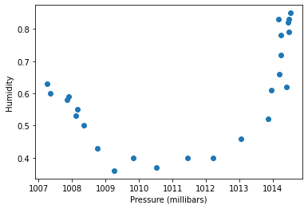

```python
# Set our input x to Pressure, use [[]] to convert to 2D array suitable for model input
X = weather_data[["Pressure (millibars)"]]
y = weather_data.Humidity

# Produce a scatter graph of Humidity against Pressure
plt.scatter(X, y)
plt.xlabel("Pressure (millibars)")
plt.ylabel("Humidity");
```

```python
#Trying to fit Simple Linear Regression

from sklearn.linear_model import LinearRegression
lin_reg = LinearRegression()
lin_reg.fit(X, y)
```

```
LinearRegression()
```

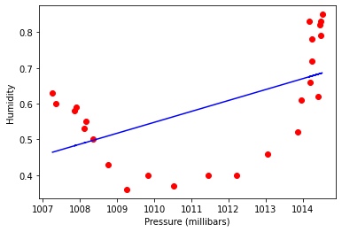

```python
#Visualising Simple Linear Regression results

plt.scatter(X, y, color = 'red')
plt.plot(X, lin_reg.predict(X), color = 'blue')
plt.xlabel("Pressure (millibars)")
plt.ylabel("Humidity")
plt.show()
```

## Fitting Polynomial Regression

The implementation of polynomial regression is a two-step process. First, we transform our data into a polynomial using the `PolynomialFeatures` function from `sklearn` and then use linear regression to fit the parameters:

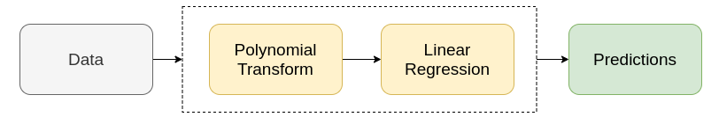

```python
# Imports

from sklearn.preprocessing import PolynomialFeatures
from sklearn.linear_model import LinearRegression
```

Set PolynomialFeatures to degree 2 and store in the variable pre_process. Degree 2 preprocesses x to 1, x and x^2, Degree 3 preprocesses x to 1, x, x^2 and x^3 and so on..

```python
pre_process = PolynomialFeatures(degree=2)

# Transform our x input to 1, x and x^2
X_poly = pre_process.fit_transform(X)

# Show the transformation on the notebook
# print(X_poly)
```

The code above makes the following transformation in `X`:

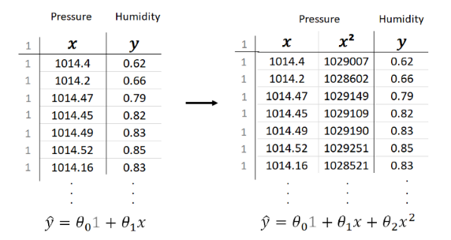

```python
pr_model = LinearRegression()

# Fit our preprocessed data to the polynomial regression model
pr_model.fit(X_poly, y)

# Store our predicted Humidity values in the variable y_new
y_pred = pr_model.predict(X_poly)
```

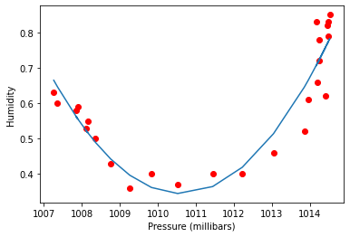

```python
# Visulaizing our Polynomial Regression Model
plt.scatter(X, y, c = "red")
plt.plot(X, y_pred)
plt.xlabel("Pressure (millibars)")
plt.ylabel("Humidity")
plt.show()
```